# Linear Algebra Tutorial

2/3/2021

## Why learn linear algebra?

Applications include:

- differential equations and dynamical systems
- Markov chains
- circuits
- social network analyses
- frequency analysis
- Google’s Page Rank algorithm
- machine learning

Goal of this tutorial: Explain linear models (regression) using linear algebra

## Vectors

- A **vector** is a list of numbers.
- The dimension of a vector is the same as its length.

**Example:** if \(v = (42, \pi, 0, -e)\) then \(\dim(v) = 4\)

**Example:** \(v = (4, 3)\)

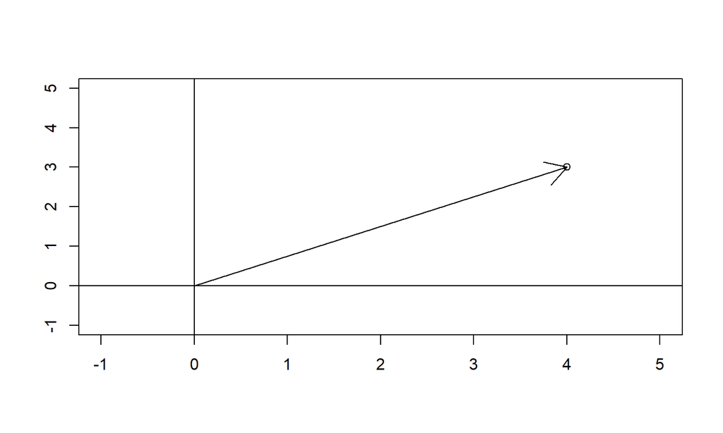

## Basis

- A **basis** is a coordinate system
- In 2D we typically use the **Euclidean basis** with basis vectors \(\hat{i}=(1,0)\) and \(\hat{j}=(0,1)\)

**Example:** The vector \((4,3)\) in the Euclidean basis is written as such because \[ \begin{pmatrix} 4 \\ 3 \end{pmatrix} = 4\begin{pmatrix} 1 \\ 0 \end{pmatrix} + 3\begin{pmatrix} 0 \\ 1\end{pmatrix} \] Say we want to change basis to using \(v_1 = (1,2)\) and \(v_2 = (1.5, 0.5)\) instead. Observe, \[ \begin{pmatrix} 4 \\ 3 \end{pmatrix} = 1\begin{pmatrix} 1 \\ 2 \end{pmatrix} + 2\begin{pmatrix} 1.5 \\ 0.5 \end{pmatrix} \] so \((4,3)\) is actually written as \((1,2)\) in this new basis.

## Matrices

- [Linear transformations and matrices](https://www.youtube.com/watch?v=kYB8IZa5AuE&list=PLZHQObOWTQDPD3MizzM2xVFitgF8hE_ab&index=3)
- [Inverse matrices, column space and null space](https://www.youtube.com/watch?v=uQhTuRlWMxw&list=PLZHQObOWTQDPD3MizzM2xVFitgF8hE_ab&index=7)

## Application: Linear Models

- Consider an additive model with \(p\) predictors.
- The model for the \(i\)th observation is

\[ y_i = \beta_0 + \beta_1x_{i1} + \beta_2x_{i2} + \cdots + \beta_nx_{ip} + \varepsilon_i \]

- If we wrote out the model for all \(n\) observations it would be

\[ \begin{align} y_1 &= \beta_0 + \beta_1 x_{11} + \beta_2 x_{12} + \cdots + \beta_p x_{1p} + \varepsilon_1\\ y_2 &= \beta_0 + \beta_1 x_{21} + \beta_2 x_{22} + \cdots + \beta_p x_{2p} + \varepsilon_2\\ &\hspace{2mm}\vdots\\ y_n &= \beta_0 + \beta_1 x_{n1} + \beta_2 x_{n2} + \cdots + \beta_p x_{np} + \varepsilon_n \end{align} \]

## Application: Linear Models

- Let \(X\) be \(n \times (p+1)\) where \(X_{\cdot 1}=1\) and \((X)_{ij}\) is the \((j-1)\)th predictor, \(j = 2,\ldots,p+1\), for the \(i\)th observation
- \(X\) is called the **design matrix**
- The previous system of equations can be written compactly as \[ y = X\beta + \varepsilon \] where \(\dim(y) = \dim(\varepsilon) = n\) and \(\beta = (\beta_0, \beta_1, \ldots, \beta_p)\)

## Application: Linear Models

Want to find the “best” estimates of \(\beta\)

- Least squares
  - Find \(\hat{\mathbf{y}} = \mathbf{X}\hat{\beta}\) that minimizes \(\sum_{i = 1}^n (\hat{y_i} - y_i)^2\)
  - Take the derivative of sum of squares, set to zero, show this is a minimum (Gauss-Markov Theorem)
- Or using linear algebra

## Application: Linear Models

Simple example

\[ \mathbf{y} = \begin{pmatrix} 2 \\ 2 \\ 1 \end{pmatrix}, \mathbf{X} = \begin{pmatrix} 1 & 4 \\ 1 & 3 \\ 1 & 4 \end{pmatrix}, \mathbf{\beta} = \begin{pmatrix} \beta_0 \\ \beta_1 \end{pmatrix} \]

The equation \(\mathbf{y} = \mathbf{X}\beta\) doesn’t have a solution because it’s overdetermined - two unknowns and 3 equations

## Application: Linear Models

\((\beta_0, \beta_1)\) is the coordinates of \(\mathbf{X}\beta\) in the column space of \(\mathbf{X}\):

\[ \begin{align} \mathbf{X}\beta &= \begin{pmatrix} 1 & 4 \\ 1 & 3 \\ 1 & 4 \end{pmatrix} \begin{pmatrix} \beta_0 \\ \beta_1 \end{pmatrix}\\ &= \beta_0 \begin{pmatrix} 1 \\ 1 \\ 1 \end{pmatrix} + \beta_1 \begin{pmatrix} 4 \\ 3 \\ 4 \end{pmatrix} \end{align} \]

If \(\mathbf{y}\) is **not** in the column space of \(\mathbf{X}\), then there is no \(\beta\) such that \(\mathbf{y} = \mathbf{X}\beta\)

We want to choose \(\hat{\beta}\) so that \(\mathbf{X}\hat{\beta}\) is as close as possible to \(\mathbf{y}\)

[figure not shown]

Stpasha, Public domain, via Wikimedia Commons

## Application: Linear Models

Project \(\mathbf{y}\) onto column space of \(\mathbf{X}\)

\[\mathbf{X}\hat{\beta} = \mathbf{X}(\mathbf{X}^T \mathbf{X})^{-1} \mathbf{X}^T \mathbf{y} = \mathbf{P}\mathbf{y}\]

\(\mathbf{P}\) is the projection matrix

\(\hat{\beta} = (\mathbf{X}^T \mathbf{X})^{-1} \mathbf{X}^T \mathbf{y}\)

## Application: Linear Models

```r
x <- cbind(c(1, 1, 1), c(4, 3, 4))
p <- x %*% solve(t(x) %*% x) %*% t(x)
p
```

```
##      [,1] [,2] [,3]
## [1,]  0.5    0  0.5
## [2,]  0.0    1  0.0
## [3,]  0.5    0  0.5
```

```r
y <- c(2, 2, 1)
p %*% y
```

```
##      [,1]
## [1,]  1.5
## [2,]  2.0
## [3,]  1.5
```

## Application: Linear Models

\[ \mathbf{P}\mathbf{y} = \begin{pmatrix} 1.5 \\ 2 \\ 1.5 \end{pmatrix} = 3.5 \begin{pmatrix} 1 \\ 1 \\ 1 \end{pmatrix} - 0.5 \begin{pmatrix} 4 \\ 3 \\ 4 \end{pmatrix} \]

So

\(\beta_0 = 3.5, \beta_1 = - 0.5\)

## Application: Linear Models

```r
lm(y ~ x - 1)
```

```
##
## Call:
## lm(formula = y ~ x - 1)
##
## Coefficients:
##   x1    x2
##  3.5  -0.5
```

## Application: Linear Models

\[Y = \begin{pmatrix} y_{11} & y_{12} \\ \vdots & \vdots \\ y_{n1} & y_{n2} \end{pmatrix}\]

\[X = \begin{pmatrix} 1 & x_{11} \\ \vdots & \vdots \\ 1 & x_{n1} \end{pmatrix}\]

\[\beta = \begin{pmatrix} \beta_{01} & \beta_{02} \\ \beta_{11} & \beta_{12} \end{pmatrix}\]

## Application: Linear Models

```r
x <- cbind(rep(1, 10), 0.1*1:10)
y <- cbind(rnorm(10, x %*% c(4, 2)), rnorm(10, x %*% c(6, 1), 0.3))
betahat <- solve(t(x) %*% x) %*% t(x) %*% y
betahat
```

```
##          [,1]     [,2]
## [1,] 4.590828 5.928296
## [2,] 1.289211 1.179707
```

```r
lm_res <- lm(y ~ x - 1)
lm_res$coefficients
```

```
##        [,1]     [,2]
## x1 4.590828 5.928296
## x2 1.289211 1.179707
```